# Assessing the Association Between Variables

Oscar Rodriguez de Rivera

In this worksheet we will consider how we can assess the association between two variables in R.

### Chi-squared test for contingency tables

Another use of the chi-squared test is to explore the relationship between the variables in a two-way contingency table. In this case, we ask whether the levels of one variable affect the distribution of the other variable.

- **Exercise 1.1**

Consider the following contingency table where we want to examine whether there is an association between marital status and alcohol consumption.

[output not shown]

State the null and alternative hypotheses:

$\text{H}_0$: there is no association between marital status and alcohol consumption (i.e. they are independent) versus $\text{H}_1$: there is an association between marital status and alcohol consumption.

Download Table1.csv from Moodle and import it into R. Use the chi-squared test to learn whether there’s an association between marital status and alcohol consumption.

```r
data1<-read.csv("~/Dropbox/Rcourse/day3/Table1.csv")
chisq.test(data1[,2:4])
```

```
##
##  Pearson's Chi-squared test
##
## data:  data1[, 2:4]
## X-squared = 94.269, df = 6, p-value < 2.2e-16
```

The p-value is very small and certainly less than 0.001, so the result is significant at the 0.1% significance level. There is very strong evidence to suggest that marital status and alcohol consumption are associated.

### Testing correlation between two variables

When studying the correlation between two random variables we want to measure the strength of their relationship. We want to know whether their relationship is positive or negative and whether it is linear or not. We have seen before that graphically we can do this using a scatter plot and we can also use the Pearson correlation coefficient to measure the strength of linear correlation. In addition, often we may want to test:

$$\text{H}_{0}: \rho = 0 \ \ \ versus \ \ \ \text{H}_1: \rho \neq 0$$

The test statistic is given by $T=R \sqrt{\frac{n-2}{1-R^2}}$ and we reject $\text{H}_0$ at the $100\alpha\%$ level if $|T| > t_{n-2, \alpha/2}$

- **Exercise 2.1**

Consider the following table of paired blood pressure measurements from 15 patients:

```r
SysBP <-c(210,169,187,160,167,176,185,206,173,146,174,201,198,148,154); DiasBP<-c(130,122,124,104,112,101,121,124,115,102,98,119,106,107,100)
cbind(SysBP,DiasBP)
```

```
##       SysBP DiasBP
##  [1,]   210    130
##  [2,]   169    122
##  [3,]   187    124
##  [4,]   160    104
##  [5,]   167    112
##  [6,]   176    101
##  [7,]   185    121
##  [8,]   206    124
##  [9,]   173    115
## [10,]   146    102
## [11,]   174     98
## [12,]   201    119
## [13,]   198    106
## [14,]   148    107
## [15,]   154    100
```

Test whether there is a linear association between systolic blood pressure and diastolic blood pressure.

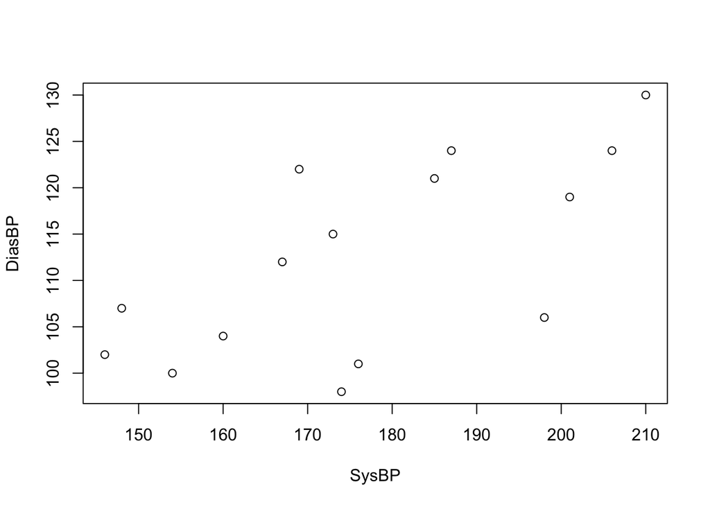

```r
plot(SysBP,DiasBP)
```

Now test for a non-zero correlation:

```r
cor.test(SysBP,DiasBP)
```

```
##
##  Pearson's product-moment correlation
##
## data:  SysBP and DiasBP
## t = 3.2085, df = 13, p-value = 0.006855
## alternative hypothesis: true correlation is not equal to 0
## 95 percent confidence interval:
##  0.2312651 0.8780322
## sample estimates:
##       cor
## 0.6647732
```

**What can you conclude? Is there evidence of a linear association between the variables?**

The p-value indicates that the test statistic of t = 3.2085 is significant at the 1% level, so there is strong evidence of a linear association between systolic and diastolic blood pressure.

The following command calculates Spearman’s rank correlation:

```r
cor.test(SysBP,DiasBP,method="spearman")
```

```
## Warning in cor.test.default(SysBP, DiasBP, method = "spearman"): Cannot compute
## exact p-value with ties
```

```
##
##  Spearman's rank correlation rho
##
## data:  SysBP and DiasBP
## S = 222.7, p-value = 0.01749
## alternative hypothesis: true rho is not equal to 0
## sample estimates:
##       rho
## 0.6023237
```

### Exercises

- **Exercise 3.1**

The dataset `accidents.csv` summarises the results from a survey on the number of car accidents in Kent in 2016. The age of the drivers who were involved in the accident and whether the accident was minor or major have been reported. Test whether the two variables, age and minor/major accident are associated.